# Dino Metabolisim Reanalysis

This markdown file is meant to illustrate workflow (at a high level) for our reanalysis of Weimann *et al.* 2022. Broadly, we correct a single erroneous calibration point and reanalyse the data following their presumed workflow. We then simulate data from re calibrated *MC in vivo* values and ask about their classification success.

# Apply Prediction Interval to original data

## Linear model of orginal data as in Figure 1d.

```
##
## Call:
## lm(formula = Log.10..Upper.MR ~ Log.10..Body.Mass..g., data = dat.lm)
##
## Residuals:
##     Min      1Q  Median      3Q     Max
## -3.3108 -0.0774  0.1558  0.2458  0.5896
##
## Coefficients:
##                       Estimate Std. Error t value Pr(>|t|)
## (Intercept)            0.44194    0.18225   2.425   0.0188 *
## Log.10..Body.Mass..g.  1.01087    0.04317  23.416   <2e-16 ***
## ---
## Signif. codes:  0 '***' 0.001 '**' 0.01 '*' 0.05 '.' 0.1 ' ' 1
##
## Residual standard error: 0.5601 on 53 degrees of freedom
## Multiple R-squared:  0.9119, Adjusted R-squared:  0.9102
## F-statistic: 548.3 on 1 and 53 DF,  p-value: < 2.2e-16
```

We first deal with the issue of appropriate predictive tests of the original data and framework. Weimann *et al.* used a 95% confidence interval to “predict” unknown thermal regimes. But confidence intervals are inappropriate for predicting unknown values. Prediction intervals are a more appropriate classification tool–relating directly to a model’s ability to predict new data. We generate prediction intervals for known endotherms and known other (thermy) based on the unaltered Weimann *et al.* data. It is important to understand the overlap between prediction intervals parameterized from known data in order to evaluate the predictive power of Weimann *et al.’s* framework.

## Plot prediction intervals

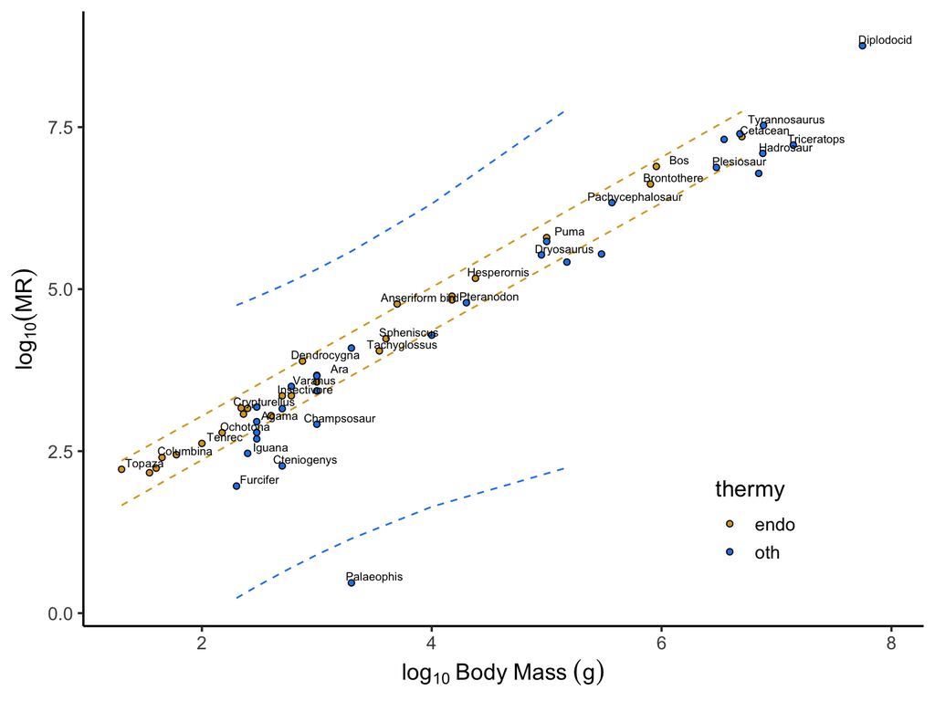

Blue points are non-endotherm samples and yellow points are endotherm samples as designated by Weimann *et al.* 2022. Yellow dashed lines are upper and lower bounds of prediction interval for known endotherm only linear model. Blue dashed lines delineate prediction interval for known other points. Note the prediction interval for known other encompasses 100% of known endotherm points (if extrapolated).

# Calibration issues

The value of 11 for Anseriform duck which drives the Weimann et al. 2022 calibration (Figure 1B) is from Legendre 2016 by way of Montes 2007 where they measured RMR in captive *Anas platyrynchos* ducklings in *mL* O<sub>2</sub> * h<sup>-1</sup> * g<sup>-1</sup> in Montes and used an allometric correction in Legendre *mL* O<sub>2</sub> * h<sup>-1</sup> * g<sup>-0.67</sup> for the same values. Weimann et al. use the allometrically corrected duck value with an uncorrected axis and possibly uncorrected values for other taxa inflating the positive relationship between Literature MR and Amide derived values.

Therefore the value in Figure 1b for the Anseriform duck reads 11 but it should in fact be 2.35 based on calculation from the original source Montes et al. 2007.

Here are two linear models. The first is the model they used for fossil calibration in Weimann *et al.* 2022. The second is the model with a corrected value for the Duck point.

```
##
## Call:
## lm(formula = Literature.MR..mL.O2...1.h...1.g. ~ X.S.N..Amide...MC.in.vivo,
##     data = .)
##
## Residuals:
##      Min       1Q   Median       3Q      Max
## -1.85428 -1.29912  0.08717  0.90988  2.00367
##
## Coefficients:
##                           Estimate Std. Error t value Pr(>|t|)
## (Intercept)                -3.9082     1.2911  -3.027 0.023189 *
## X.S.N..Amide...MC.in.vivo   1.3000     0.2155   6.033 0.000937 ***
## ---
## Signif. codes:  0 '***' 0.001 '**' 0.01 '*' 0.05 '.' 0.1 ' ' 1
##
## Residual standard error: 1.532 on 6 degrees of freedom
## Multiple R-squared:  0.8585, Adjusted R-squared:  0.8349
## F-statistic: 36.39 on 1 and 6 DF,  p-value: 0.0009374
```

```
##
## Call:
## lm(formula = Literature.MR..mL.O2...1.h...1.g. ~ X.S.N..Amide...MC.in.vivo,
##     data = .)
##
## Residuals:
##     Min      1Q  Median      3Q     Max
## -1.5658 -1.2722 -0.6168  0.3821  3.7131
##
## Coefficients:
##                           Estimate Std. Error t value Pr(>|t|)
## (Intercept)                 0.3371     1.6915   0.199    0.849
## X.S.N..Amide...MC.in.vivo   0.3207     0.2823   1.136    0.299
##
## Residual standard error: 2.007 on 6 degrees of freedom
## Multiple R-squared:  0.177,  Adjusted R-squared:  0.03981
## F-statistic:  1.29 on 1 and 6 DF,  p-value: 0.2993
```

## Plot R<sup>2</sup> with/without corrected calibration

Visualize the calibration according to the supplementary data calibration tab n=8 extant amniotes and calibration with duck removed.

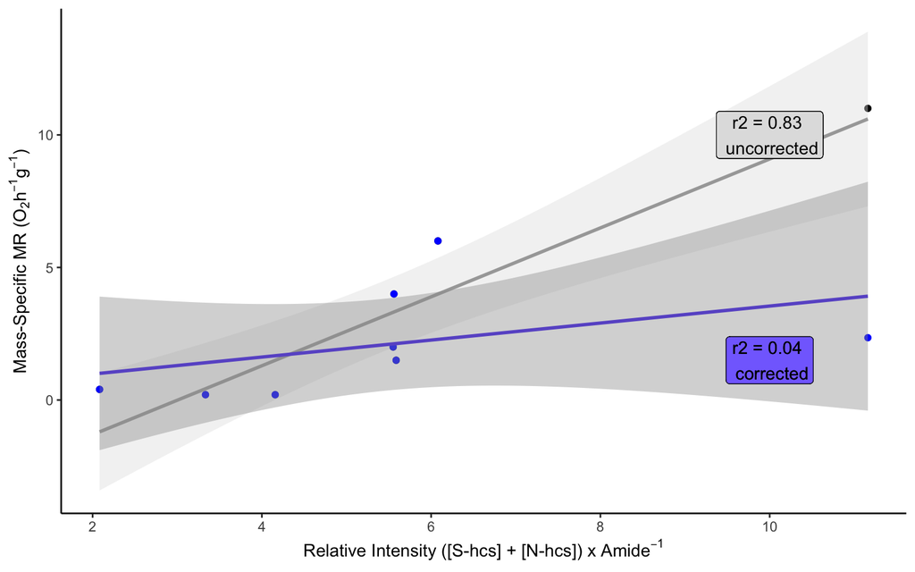

Grey line shows original calibration linear model with SE bands. Purple line shows corrected linear model with SE bands. The relationship all but disappears after correcting the duck point…

## Second calibration for extant taxa

It appears there were two calibrations(?) One for fossil taxa above and one for extant taxa (See Figure S7 and ‘Extant Taxa’ tab from supplementary workbook from Weimann et al. 2022)

They regressed n=25 literature MR values (not cited??) from spectral Amide ( *MC in vivo*) values from museum samples. We know from the literature that again this duck point ( *Dendrocygna*) cannot be correct (much higher than hummingbird). So, in absence of the known lit-derived value we will remove this point from our calibration. Second, we can see and suspect intense phylogenetic signal within this calibration and would like to correct for it. We will use the tree that Weimann *et al.* used to run a PGLS model.

```
##
## Call:
## lm(formula = Literature.MR..mL.O2...1.h...1.g. ~ X.S.N..Amide...MC.in.vivo..normalized.spectral.intensities.,
##     data = .)
##
## Residuals:
##     Min      1Q  Median      3Q     Max
## -2.9597 -0.8089  0.1948  0.9427  2.7180
##
## Coefficients:
##                                                             Estimate Std. Error
## (Intercept)                                                   -8.060      1.763
## X.S.N..Amide...MC.in.vivo..normalized.spectral.intensities.    9.527      1.393
##                                                             t value Pr(>|t|)
## (Intercept)                                                  -4.573 0.000135
## X.S.N..Amide...MC.in.vivo..normalized.spectral.intensities.   6.842 5.62e-07
##
## (Intercept)                                                 ***
## X.S.N..Amide...MC.in.vivo..normalized.spectral.intensities. ***
## ---
## Signif. codes:  0 '***' 0.001 '**' 0.01 '*' 0.05 '.' 0.1 ' ' 1
##
## Residual standard error: 1.597 on 23 degrees of freedom
## Multiple R-squared:  0.6705, Adjusted R-squared:  0.6562
## F-statistic: 46.81 on 1 and 23 DF,  p-value: 5.622e-07
```

```
##
## Call:
## lm(formula = Literature.MR..mL.O2...1.h...1.g. ~ X.S.N..Amide...MC.in.vivo..normalized.spectral.intensities.,
##     data = .)
##
## Residuals:
##     Min      1Q  Median      3Q     Max
## -2.7146 -0.9872  0.2600  1.0818  2.6010
##
## Coefficients:
##                                                             Estimate Std. Error
## (Intercept)                                                   -6.141      1.897
## X.S.N..Amide...MC.in.vivo..normalized.spectral.intensities.    7.867      1.534
##                                                             t value Pr(>|t|)
## (Intercept)                                                  -3.237  0.00379
## X.S.N..Amide...MC.in.vivo..normalized.spectral.intensities.   5.127 3.88e-05
##
## (Intercept)                                                 **
## X.S.N..Amide...MC.in.vivo..normalized.spectral.intensities. ***
## ---
## Signif. codes:  0 '***' 0.001 '**' 0.01 '*' 0.05 '.' 0.1 ' ' 1
##
## Residual standard error: 1.496 on 22 degrees of freedom
## Multiple R-squared:  0.5444, Adjusted R-squared:  0.5237
## F-statistic: 26.28 on 1 and 22 DF,  p-value: 3.877e-05
```

## Phylogentic Least Squares Model for Extant Calibration

### PGLS using Time tree from Weimann *et al.* 2022 (Iris Mendez’ Github)

```
## Generalized least squares fit by REML
##   Model: Literature.MR..mL.O2...1.h...1.g. ~ X.S.N..Amide...MC.in.vivo..normalized.spectral.intensities.
##   Data: pgls.dat
##        AIC      BIC    logLik
##   94.24712 97.52025 -44.12356
##
## Correlation Structure: corPagel
##  Formula: ~Taxon.Name
##  Parameter estimate(s):
## lambda
##      1
## Variance function:
##  Structure: fixed weights
##  Formula: ~w
##
## Coefficients:
##                                                                 Value Std.Error
## (Intercept)                                                 -3.937516  2.497542
## X.S.N..Amide...MC.in.vivo..normalized.spectral.intensities.  5.915003  1.952371
##                                                               t-value p-value
## (Intercept)                                                 -1.576556  0.1292
## X.S.N..Amide...MC.in.vivo..normalized.spectral.intensities.  3.029651  0.0062
##
##  Correlation:
##                                                             (Intr)
## X.S.N..Amide...MC.in.vivo..normalized.spectral.intensities. -0.877
##
## Standardized residuals:
##         Min          Q1         Med          Q3         Max
## -0.89555782 -0.44434793  0.08615599  0.52266282  0.97616185
##
## Residual standard error: 0.1490233
## Degrees of freedom: 24 total; 22 residual
```

We see that a pure Brownian Motion model with high phylo signal and *Dendrocygna* removed reduces the slope of the extant calibration from 9.5273 to 5.915003 and increases the intercept from -8.0604 to -3.937516.

Next we will run a model with a starting value of *lamda* at zero.

```
## Generalized least squares fit by REML
##   Model: Literature.MR..mL.O2...1.h...1.g. ~ X.S.N..Amide...MC.in.vivo..normalized.spectral.intensities.
##   Data: pgls.dat
##        AIC      BIC    logLik
##   91.13967 95.50384 -41.56983
##
## Correlation Structure: corPagel
##  Formula: ~Taxon.Name
##  Parameter estimate(s):
##    lambda
## 0.1720322
## Variance function:
##  Structure: fixed weights
##  Formula: ~w
##
## Coefficients:
##                                                                 Value Std.Error
## (Intercept)                                                 -5.627356  1.961022
## X.S.N..Amide...MC.in.vivo..normalized.spectral.intensities.  7.414920  1.605407
##                                                               t-value p-value
## (Intercept)                                                 -2.869603  0.0089
## X.S.N..Amide...MC.in.vivo..normalized.spectral.intensities.  4.618716  0.0001
##
##  Correlation:
##                                                             (Intr)
## X.S.N..Amide...MC.in.vivo..normalized.spectral.intensities. -0.977
##
## Standardized residuals:
##        Min         Q1        Med         Q3        Max
## -1.6916999 -0.6742551  0.1202029  0.7409798  1.6990248
##
## Residual standard error: 0.08771565
## Degrees of freedom: 24 total; 22 residual
```

We see that a pure Brownian Motion model with high phylo signal and *Dendrocygna* removed reduces the slope of the extant calibration from 9.5273 to 7.414920 and increases the intercept from -8.0604 to -5.627356. The model estimates *lamda* at 0.17, pretty low phylo signal.

```
##                 Model df      AIC      BIC    logLik   Test  L.Ratio p-value
## pglsModel.pgl.0     1  4 91.13967 95.50384 -41.56983
## pglsModel.pgl.1     2  3 94.24712 97.52025 -44.12356 1 vs 2 5.107452  0.0238
```

Models selection favors the low phylo signal model.

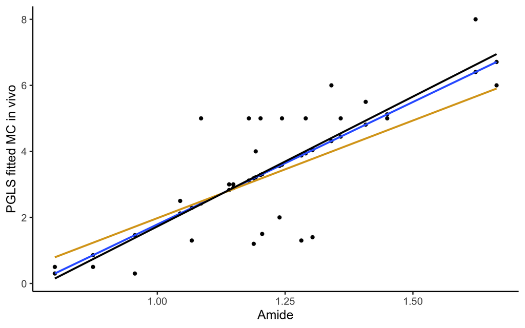

This plot shows the two PGLS regression lines from the tree they used for their figures, ancestral state reconstruction and, presumably, PGLS. The black line is just uncorrected linear model. The blue line is essentially identical to uncorrected linear regression.This is the line supported by model selection. The yellow line is the model forcing a high level of phylo signal ( *lamda* = 1).This line is not suported. *Lamda* is estimated at ~ 0.17 by “best” model.

### PGLS using Time tree from timetree.org

```
## Generalized least squares fit by REML
##   Model: Literature.MR..mL.O2...1.h...1.g. ~ X.S.N..Amide...MC.in.vivo..normalized.spectral.intensities.
##   Data: pgls.dat2
##       AIC      BIC   logLik
##   96.2564 99.52952 -45.1282
##
## Correlation Structure: corPagel
##  Formula: ~Taxon.Name
##  Parameter estimate(s):
## lambda
##      1
##
## Coefficients:
##                                                                 Value Std.Error
## (Intercept)                                                 -4.332293  2.191044
## X.S.N..Amide...MC.in.vivo..normalized.spectral.intensities.  6.284117  1.468292
##                                                               t-value p-value
## (Intercept)                                                 -1.977274  0.0607
## X.S.N..Amide...MC.in.vivo..normalized.spectral.intensities.  4.279883  0.0003
##
##  Correlation:
##                                                             (Intr)
## X.S.N..Amide...MC.in.vivo..normalized.spectral.intensities. -0.809
##
## Standardized residuals:
##         Min          Q1         Med          Q3         Max
## -0.89979017 -0.42083237  0.07089611  0.47438410  0.91827065
##
## Residual standard error: 2.733929
## Degrees of freedom: 24 total; 22 residual
```

We see that a pure Brownian Motion model with high phylo signal and *Dendrocygna* removed reduces the slope of the extant calibration from 9.5273 to 6.284117 and increases the intercept from -8.0604 to -4.332293

Next we will run a model with a starting value of *lamda* at zero.

```
## Generalized least squares fit by REML
##   Model: Literature.MR..mL.O2...1.h...1.g. ~ X.S.N..Amide...MC.in.vivo..normalized.spectral.intensities.
##   Data: pgls.dat2
##       AIC      BIC    logLik
##   91.2505 95.61467 -41.62525
##
## Correlation Structure: corPagel
##  Formula: ~Taxon.Name
##  Parameter estimate(s):
##      lambda
## -0.03983225
##
## Coefficients:
##                                                                 Value Std.Error
## (Intercept)                                                 -6.310608  1.889181
## X.S.N..Amide...MC.in.vivo..normalized.spectral.intensities.  7.998161  1.533615
##                                                               t-value p-value
## (Intercept)                                                 -3.340394   0.003
## X.S.N..Amide...MC.in.vivo..normalized.spectral.intensities.  5.215235   0.000
##
##  Correlation:
##                                                             (Intr)
## X.S.N..Amide...MC.in.vivo..normalized.spectral.intensities. -0.99
##
## Standardized residuals:
##        Min         Q1        Med         Q3        Max
## -1.8236587 -0.6750827  0.2029145  0.7226719  1.7645384
##
## Residual standard error: 1.489397
## Degrees of freedom: 24 total; 22 residual
```

We see that a pure Brownian Motion model with high phylo signal and *Dendrocygna* removed reduces the slope of the extant calibration from 9.5273 to 7.998161 and increases the intercept from -8.0604 to -6.310608

```
##          Model df     AIC      BIC    logLik   Test  L.Ratio p-value
## tt.pgl.0     1  4 91.2505 95.61467 -41.62525
## tt.pgl.1     2  3 96.2564 99.52952 -45.12820 1 vs 2 7.005899  0.0081
```

So, we need to use the low phylosignal model which changes the original slope from 9.5273 to 7.998161 and increases the intercept from -8.0604 to -6.310608

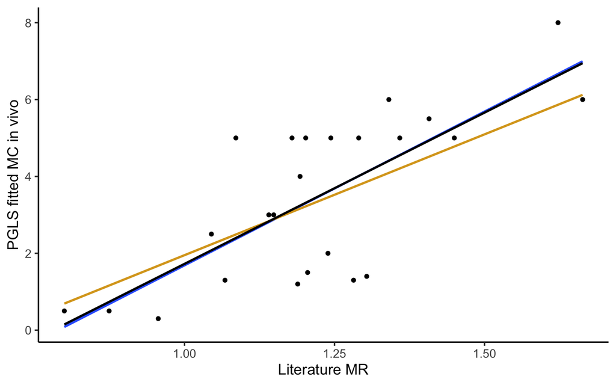

This plot shows the two PGLS regression lines from the timetree pgls. The black line is just regular linear model. The blue line (barely visible) is essentially identical to uncorrected linear regression.This is the line supported by model selection. The yellow line is the model forcing a high level of phylo signal ( *lamda* = 1).This line is not supported. *Lamda* is estimated at ~ 0.

Therefore, we will give them the benefit of the doubt and use the time tree pgls with *Dendrocygna* removed. This flattens slope slightly changing calibration formula from (9.527 * *MC in vivo*) - 8.060 to (7.998161 * *MC in vivo*) - 6.310608 for all extant taxa.

```r
# Add corrected columns for adjusted calcuatedMR and corrected
# We will give them the benefit  of the doubt and use the time tree pgls with Dendrocygna removed. This flattens slope slighlty...

 dat.calib.extant$adj_calc_MR <-(7.998161*dat.calib.extant$X.S.N..Amide...MC.in.vivo..normalized.spectral.intensities.)-6.310608
 dat.calib.extant$adj_corr_MR <-dat.calib.extant$adj_calc_MR +0.9

#This is for fun to see what applying the fossil calibration (since they used extant MRs anyway) to all extant taxa
dat.calib.extant$adj_calc_MR_foss_cab <-(0.3207*dat.calib.extant$X.S.N..Amide...MC.in.vivo..normalized.spectral.intensities.)+0.3371
dat.calib.extant$adj_corr_MR_foss_cab <-dat.calib.extant$adj_calc_MR_foss_cab +0.9
```

# Apply fossil calibration and plot it

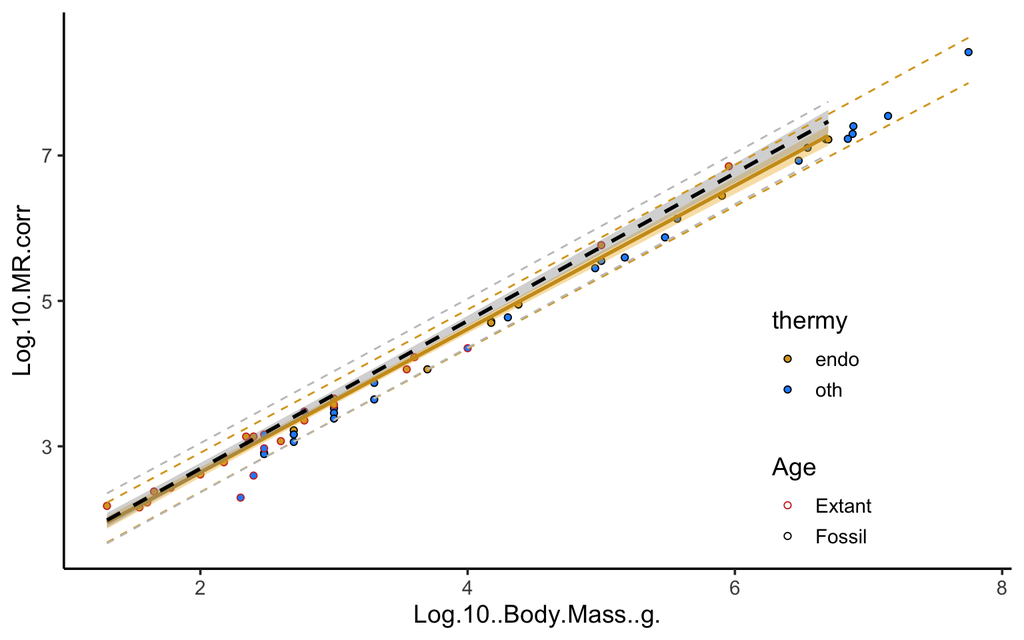

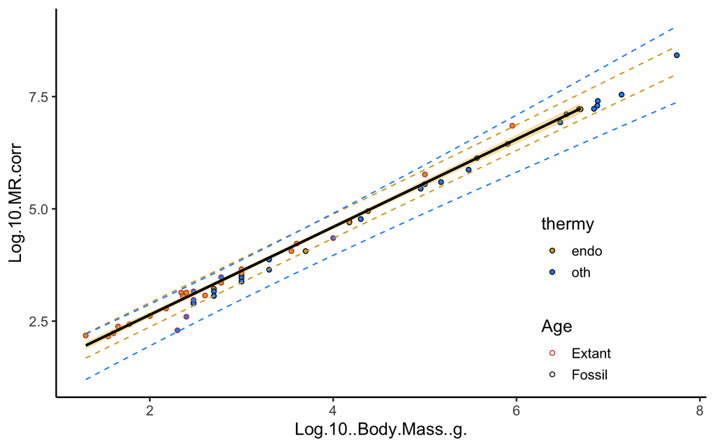

The effect of the adjusted calibration is shown here. *Left Panel* The original endotherm regression is dashed black here while the new one with adjusted calibration is dark yellow. The original endotherm PI is dashed grey and the adjusted endotherm PI is dashed yellow. At low masses they essentially predict the same MRs. *Right Panel* shows the overlap between prediction intervals for endotherms (yellow) and unknown therms (blue). Substantial overlap across entire range suggesting maybe 50/50 chance of correctly identifying thermy within this narrow range.

# Simulate data with adjusted calibration using faux package.

## Plot simulated data and overlap with CI

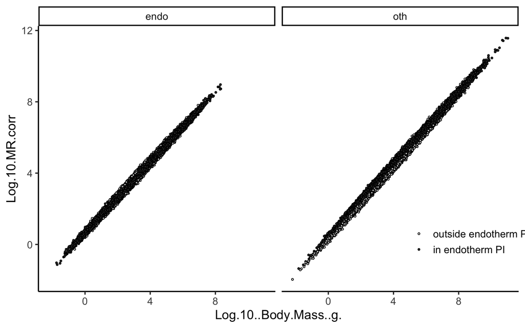

## Plot classification success

Let’s look at percentages of points classified as endotherm or other following the Weimann et al. 2022 schema.

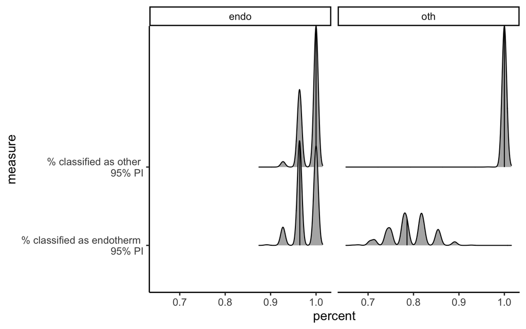

Here are distributions of percentages of simulated data points that fell within the 95% confidence interval (CI) or prediction interval (PI) for endotherms and amniotes of other/indeterminate thermy. Keep in mind that the simulated data follow the exact same means, standard deviations, and correlations as original data.

# Simulate data with adjusted calibration using MASS package.

```
## # A tibble: 3 × 6
##   thermy_3_cat    mean.mass var.mass mean.mr var.mr   cnt
##   <fct>               <dbl>    <dbl>   <dbl>  <dbl> <int>
## 1 known endotherm      3.37    2.37     3.98  2.28     28
## 2 known other          2.97    0.658    3.39  0.706    13
## 3 unknown              5.80    2.45     6.28  2.59     13
```

```
##                       Log.10.MR.corr
## Log.10..Body.Mass..g.        2.32094
```

```
##                       Log.10.MR.corr
## Log.10..Body.Mass..g.      0.6648198
```

```
##                       Log.10.MR.corr
## Log.10..Body.Mass..g.       2.515305
```

## Plot simulated data and overlap with CI

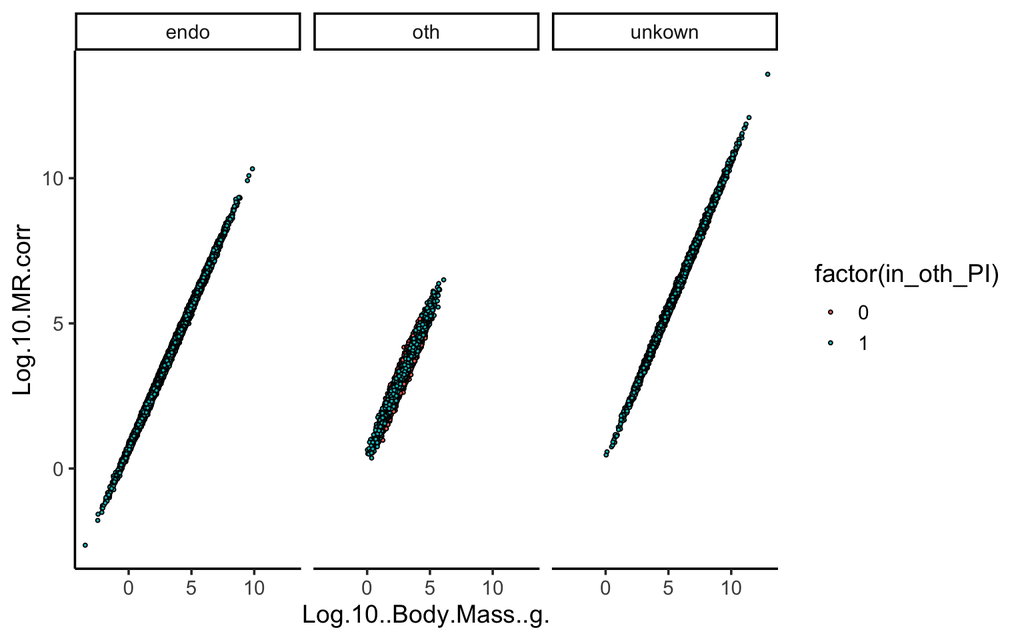

## Plot classification success

Let’s look at percentages of points classified as endotherm or other following the Weimann et al. 2022 schema.

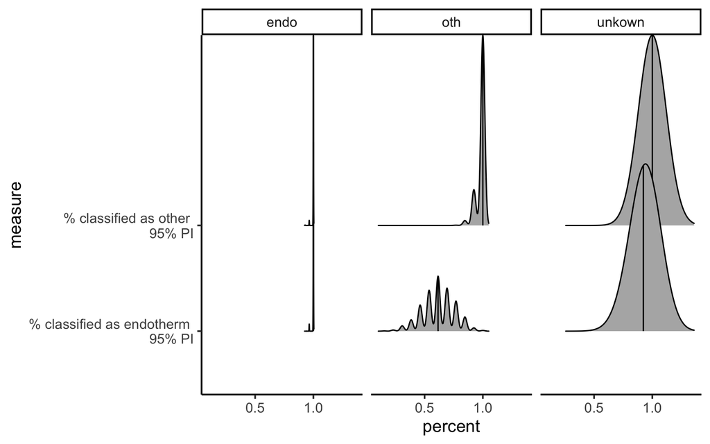

Here are distributions of percentages of simulated data points that fell within the 95% confidence interval (CI) or prediction interval (PI) for endotherms and amniotes of other/indeterminate thermy. Keep in mind that the simulated data follow the exact same means, standard deviations, and correlations as original data.

```
## # A tibble: 3 × 4
##   thermy   cnt perc_in_endo_PI perc_in_oth_PI
##   <chr>  <int>           <dbl>          <dbl>
## 1 endo   28000           0.999          0.999
## 2 oth    13000           0.617          0.985
## 3 unkown 13000           0.934          1
```

# In light of John Grady’s framework

Finally, we use John Grady’s conceptual framework to test whether the mass specific MR shows the expected decrease with body mass or is flat consistent wiht the canceling effects of lifespan and cell metabolic rate.

## Plot mass-specific MR x mass for orginal and recalibrated data:

```
##
## Call:
## lm(formula = log10(Body.mass..g.) ~ log10(Calculated.MRs..mL.O2...1.h...1.g.) +
##     Age, data = dat.lm)
##
## Residuals:
##      Min       1Q   Median       3Q      Max
## -2.26671 -1.05017 -0.04184  0.87586  3.06580
##
## Coefficients:
##                                           Estimate Std. Error t value Pr(>|t|)
## (Intercept)                                 2.4049     0.3591   6.698 1.50e-08
## log10(Calculated.MRs..mL.O2...1.h...1.g.)   0.5150     0.3578   1.439    0.156
## AgeFossil                                   2.1783     0.3954   5.509 1.13e-06
##
## (Intercept)                               ***
## log10(Calculated.MRs..mL.O2...1.h...1.g.)
## AgeFossil                                 ***
## ---
## Signif. codes:  0 '***' 0.001 '**' 0.01 '*' 0.05 '.' 0.1 ' ' 1
##
## Residual standard error: 1.429 on 52 degrees of freedom
## Multiple R-squared:  0.3693, Adjusted R-squared:  0.3451
## F-statistic: 15.23 on 2 and 52 DF,  p-value: 6.238e-06
```

```
##
## Call:
## lm(formula = log10(adj_corr_MR) ~ Log.10..Body.Mass..g., data = full.analyses.df)
##
## Residuals:
##      Min       1Q   Median       3Q      Max
## -0.55505 -0.08721  0.01320  0.06876  0.38385
##
## Coefficients:
##                        Estimate Std. Error t value Pr(>|t|)
## (Intercept)            0.570127   0.051828  11.000 3.49e-15 ***
## Log.10..Body.Mass..g. -0.009509   0.012216  -0.778     0.44
## ---
## Signif. codes:  0 '***' 0.001 '**' 0.01 '*' 0.05 '.' 0.1 ' ' 1
##
## Residual standard error: 0.158 on 52 degrees of freedom
## Multiple R-squared:  0.01152,    Adjusted R-squared:  -0.007491
## F-statistic: 0.6059 on 1 and 52 DF,  p-value: 0.4399
```

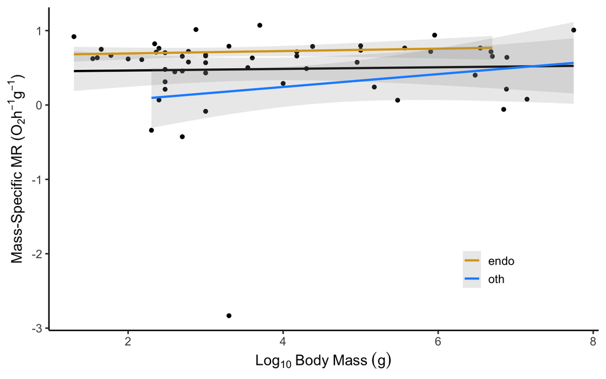

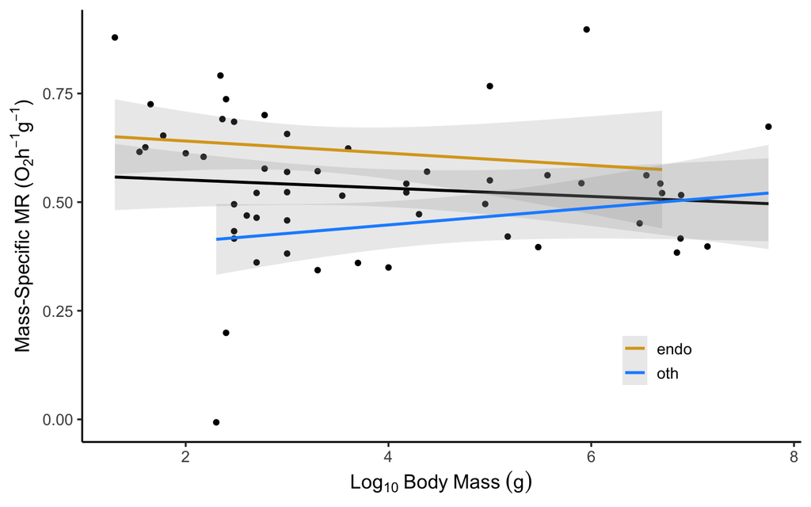

## Plot mass-specific MR x mass for extant calibration data:

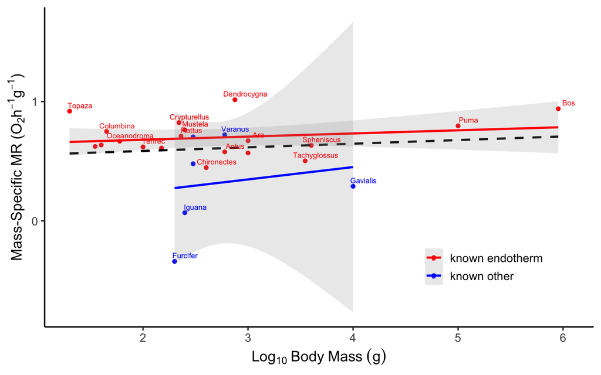

```
##
## Call:
## lm(formula = log10(Body.mass..g.) ~ log10(Calculated.MRs..mL.O2...1.h...1.g.),
##     data = dat.lm %>% filter(Age == "Extant"))
##
## Residuals:
##      Min       1Q   Median       3Q      Max
## -1.55318 -0.54273 -0.08332  0.25435  3.09127
##
## Coefficients:
##                                           Estimate Std. Error t value Pr(>|t|)
## (Intercept)                                 2.4516     0.5245   4.674 0.000105
## log10(Calculated.MRs..mL.O2...1.h...1.g.)   0.4381     0.7867   0.557 0.582956
##
## (Intercept)                               ***
## log10(Calculated.MRs..mL.O2...1.h...1.g.)
## ---
## Signif. codes:  0 '***' 0.001 '**' 0.01 '*' 0.05 '.' 0.1 ' ' 1
##
## Residual standard error: 1.08 on 23 degrees of freedom
## Multiple R-squared:  0.01331,    Adjusted R-squared:  -0.02959
## F-statistic: 0.3102 on 1 and 23 DF,  p-value: 0.583
```

The extant calibration is pulling a lot of statistical weight in the Weimann *et al.* analyses. We know that at least the *Dendrocygna* point is incorrect, but beyond that if we regress Log_10 Mass specific MR against Log_10(body mass (g)) we do not obtain the expected negative slope of (-1/4)as predicted by allometric scaling. Instead we get essentially flat (even slightly positive), non-significant relationships ( *P* = 0.583).

# Discriminant Analysis

The authors use a discriminant analysis as a validation of their question but bury it in the extended data figures and do not label points. It does not appear to end up paramterizing any of the downstream classification.

```r
set.seed(123)
training.samples <- disc.df$Taxon.Name %>%
  createDataPartition(p = 0.8, list = FALSE)
train.data <- disc.df[training.samples, ]
test.data <- disc.df[-training.samples, ]
```